# Linear models lecture

## Introduction

## Goals for today

- Introduce linear regression
- Learn how to interpret model output
- Understand diagnostic plots
- Learn about transformations

## History

- ANOVA, ANCOVA, regression, \(t\) test are all variations of the same animal, the *general* linear model
- Many people (including the R project) call it a linear model (`lm`) to distinguish it from the *generalized* linear model (`glm`)
- these models are typical fit by ordinary least squares

## Extended linear models

- *Generalized* linear models can incorporate:
  - (Some) non-linear relationships
  - Non-normal response *families* (binomial, Poisson, …)
- *Mixed* models incorporate *random effects*
  - Categories in data represent samples from a population
  - e.g. species, sites, genes …
  - Traditionally used to account for experimental blocks

## Basic theory

## Assumptions

- *Response variables* are linear functions of *input variables*, in turn based on *predictor variables*
  - Can have one or more input variables per predictor variable
  - Each input variable is associated with an estimated parameter (more about this later)
- *Errors* or *residuals* are Normally distributed
  - In other words, the difference between our model *predictions* and our observations is Normal
  - *not* assuming the marginal distribution is Normal (e.g. a histogram of an input variable)
  - (Go to board/paper for residual drawing)
- Predictor variables are independent

## Machinery

- *least squares* fit - we get parameters that minimize the squared differences between predictions and observations
- Least squares fits have a lot of nice properties
- Sensitive to some departures from the assumptions
  - anomalous events tend to have a larger effect than they should

## One-parameter variables - continuous

- Continuous predictor variable: estimate a straight line with one parameter
  - Also implies one *input variable*
- \(Y = a+bX\)
- \(Y\) is the response
- \(X\) is the input variable
- \(b\) is the *slope* and the expected change in Y per unit change in X

## One-parameter variables - categorical

- Categorical predictor variable with two categories: only one parameter
  - difference in predicted value between levels
- Parameters are (usually) easy to interpret

## You can read in batdat, each row is a bat

```r
# in this dataset, each row is a bat that
# is positive or negative for P. destructans
batdat=read.csv("bat_data.csv")
head(batdat)
```

```
##      swab_id gd        gdL swab_type state          site    date species temp
## 1 KL15WI0002  1 0.00007560       BAT    WI HORSESHOE BAY 2/27/15    MYSE   NA
## 2 KL15WI0003  1 0.47879100       BAT    WI HORSESHOE BAY 2/27/15    MYLU   NA
## 3 KL15WI0004  0         NA       BAT    WI HORSESHOE BAY 2/27/15    MYLU   NA
## 4 KL15WI0005  1 0.00000551       BAT    WI HORSESHOE BAY 2/27/15    MYLU   NA
## 5 KL15WI0006  1 0.00003560       BAT    WI HORSESHOE BAY 2/27/15    MYLU   NA
## 6 KL15WI0007  1 0.00003160       BAT    WI HORSESHOE BAY 2/27/15    MYLU   NA
##   country count
## 1    u.s.     3
## 2    u.s.  1110
## 3    u.s.  1110
## 4    u.s.  1110
## 5    u.s.  1110
## 6    u.s.  1110
```

## Some transformations (discussed more later)

```r
batdat$lgdL = log10(batdat$gdL)
batdat$lcount = log10(batdat$count)
```

## Running a linear model in R - continuous predictor

```r
mod1 = lm(lgdL~lcount, data = batdat)
summary(mod1)
```

```
##
## Call:
## lm(formula = lgdL ~ lcount, data = batdat)
##
## Residuals:
##     Min      1Q  Median      3Q     Max
## -3.0111 -0.9158 -0.1918  0.8661  3.4968
##
## Coefficients:
##             Estimate Std. Error t value Pr(>|t|)
## (Intercept)  -1.6718     0.2507  -6.669 1.75e-10 ***
## lcount       -0.7043     0.1326  -5.312 2.47e-07 ***
## ---
## Signif. codes:  0 '***' 0.001 '**' 0.01 '*' 0.05 '.' 0.1 ' ' 1
##
## Residual standard error: 1.257 on 240 degrees of freedom
##   (428 observations deleted due to missingness)
## Multiple R-squared:  0.1052, Adjusted R-squared:  0.1015
## F-statistic: 28.22 on 1 and 240 DF,  p-value: 2.471e-07
```

## Interpreting model output in R - continuous predictor

- y = ax + b / lgdL = -0.7043x + (-1.6718)
- First line - intercept (-1.6718), P-value: probability value is >0
- Second lines: labeled with parameter names
  - Predictor is *continuous* so value is slope (-0.704) (or coef)
  - The value represents the change in the predicted value of the y for each one-unit increase in the x variable (holding all other variables constant)
  - p-value: when *continuous*, the probability of observing a coefficient as extreme as the one calculated if the true coefficient were actually zero (the null hypothesis)
  - in plain language: whether your x variable has a significant effect on your y
  - Std. Error: An estimate of the uncertainty of the coef. estimate.

## Running a linear model in R - categorical predictor

```r
mod2 = lm(lgdL~species, data = batdat)
summary(mod2)
```

```
##
## Call:
## lm(formula = lgdL ~ species, data = batdat)
##
## Residuals:
##     Min      1Q  Median      3Q     Max
## -3.2199 -0.9052 -0.1714  0.8358  3.2232
##
## Coefficients:
##                  Estimate Std. Error t value Pr(>|t|)
## (Intercept)      -3.64246    0.38222  -9.530  < 2e-16 ***
## speciesMYLU       0.61607    0.39185   1.572 0.116873
## speciesMYSE      -0.04583    0.71507  -0.064 0.948939
## speciesPESU       1.60276    0.43789   3.660 0.000294 ***
## speciesSUBSTRATE -0.46844    0.40312  -1.162 0.246072
## ---
## Signif. codes:  0 '***' 0.001 '**' 0.01 '*' 0.05 '.' 0.1 ' ' 1
##
## Residual standard error: 1.209 on 326 degrees of freedom
##   (339 observations deleted due to missingness)
## Multiple R-squared:  0.2078, Adjusted R-squared:  0.1981
## F-statistic: 21.38 on 4 and 326 DF,  p-value: 1.123e-15
```

## Interpreting categorical data is trickier

- First line (labeled INTERCEPT) is actually the REFERENCE
- This is the omitted group; (EPFU) in this case
- Each other parameter listed is in REFERENCE to the estimated value of the this variable!
- e.g. speciesMYLU is saying that MYLU have, on average, 0.61607 more fungus than EPFU
- you can manually change the reference level of the variables or use other packages to change these contrasts (more on this next week)

## Diagnostics

- Because the linear model is sensitive (sometimes!) to assumptions, it is good to evaluate them
- Concerns:
  - *Heteroscedasticity* (does variance change across the data set, check diagnostic plots)
  - Linearity (does your model fit well?)
  - Normality (assuming no overall problems, do your **residuals** look Normal?)
  - Independence (no autocorrelation)
    - current value is independent of the previous (historic) values - important for time series data
- Normality is the **least important** of these assumptions

## First visualize residuals

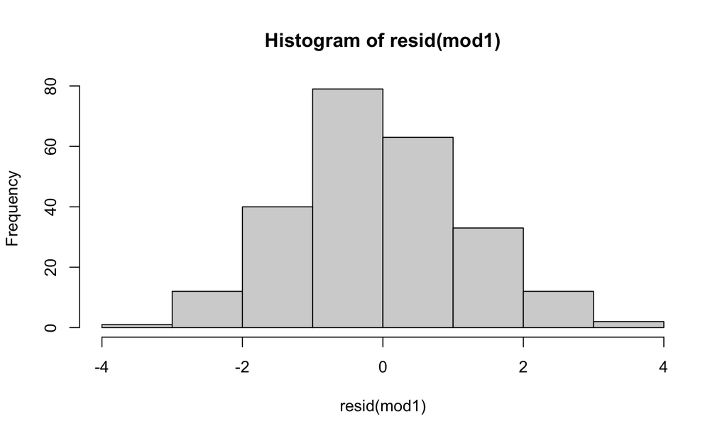

```r
hist(resid(mod1))
```

- Doesn’t look terrible, but can we be certain?

## Using qq plots

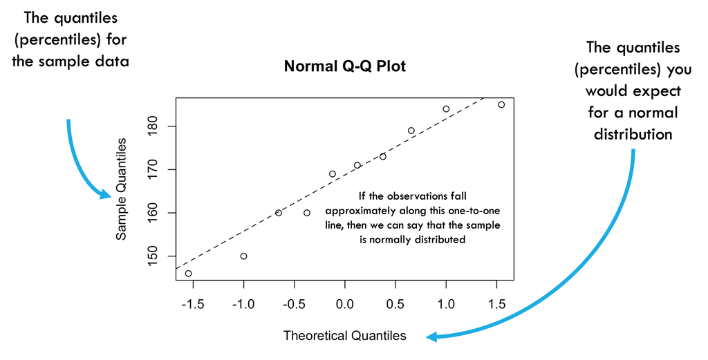

## Solving issues

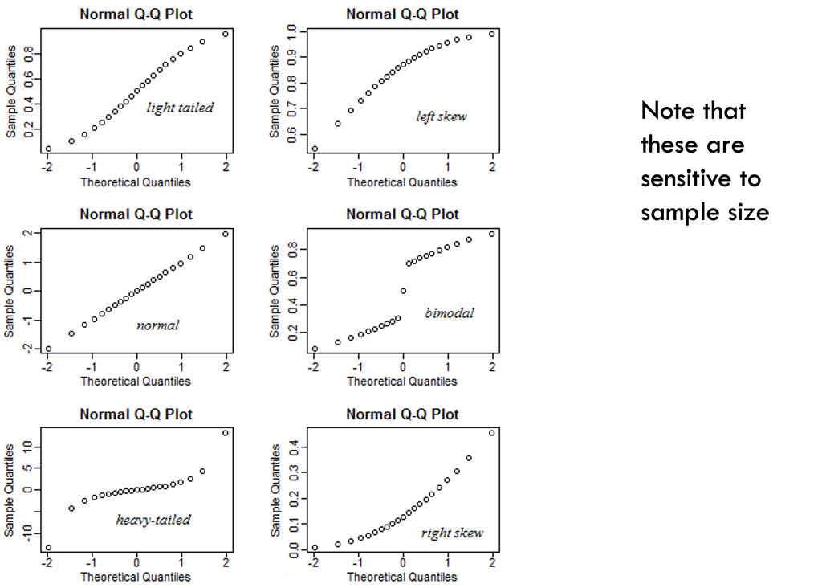

## Basic diagnostic plots in R

- use code ‘plot(mod1)’ to generate 4 diagnostic plots

```r
par(mfrow=c(2,2))  # set 2 rows and 2 column plot layout
plot(mod1)
```

[output not shown]

## Using the performance package

- The performance package is a useful package for doing model checks and improves on some of the plots in base R
- You can read more about it here:
- https://easystats.github.io/performance/
- https://easystats.github.io/see/articles/performance.html

## Basic model diagnostic plots with `performance`

- first you will need to install the package and run it

```r
#install.packages(performance)

#load performance
library(performance)
```

## Diagnostic plots using check_model in the performance package

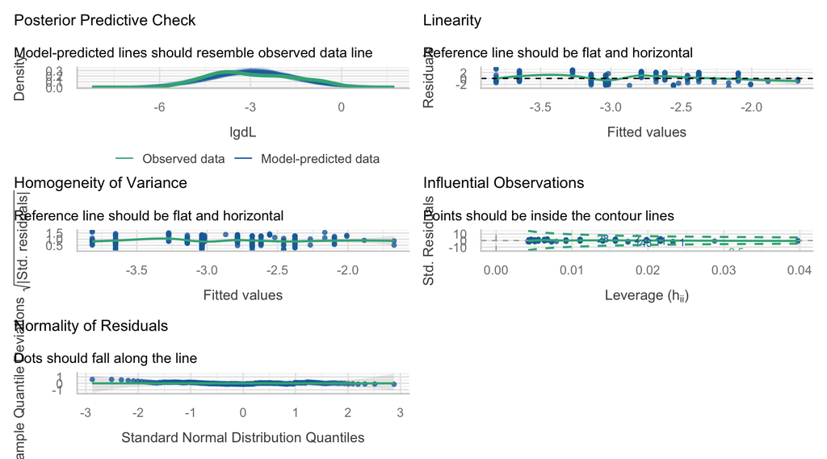

```r
check_model(mod1)
```

## Diagnostic plots using check_model - linearity

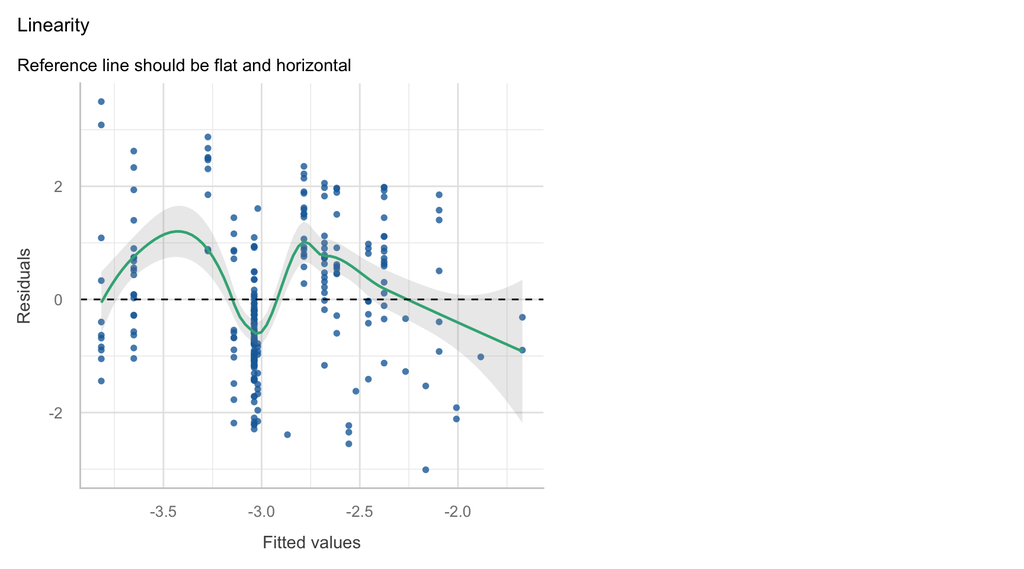

```r
check_model(mod1,  check = "linearity")
```

## Diagnostic plots using check_model - homogeneity

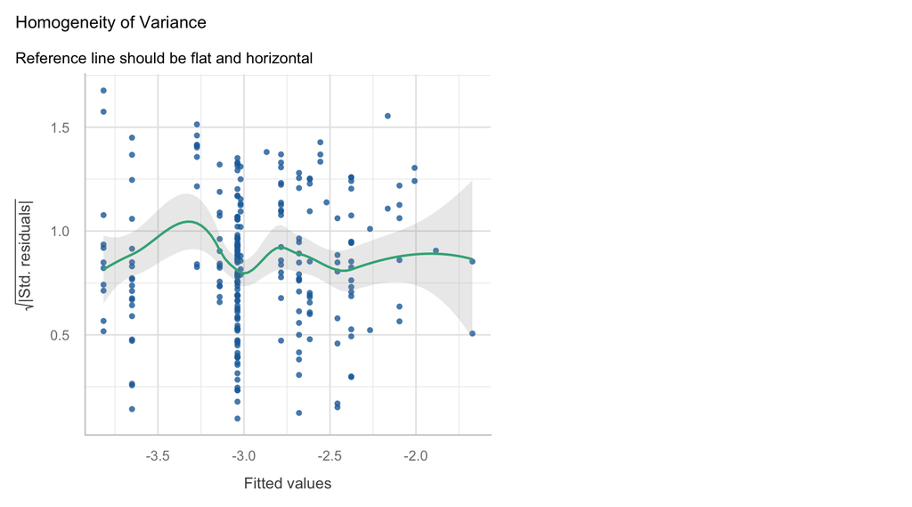

```r
check_model(mod1,  check = "homogeneity")
```

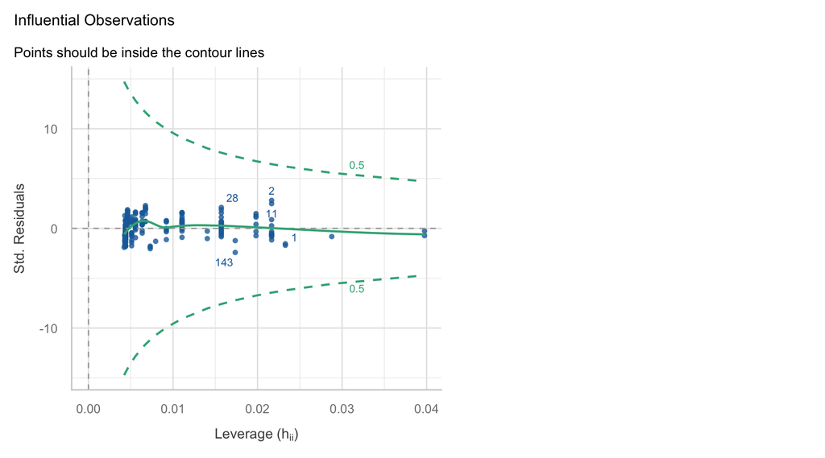

```r
check_model(mod1,  check = "outliers")
```

## Diagnostic plots using check_model - normality of residuals

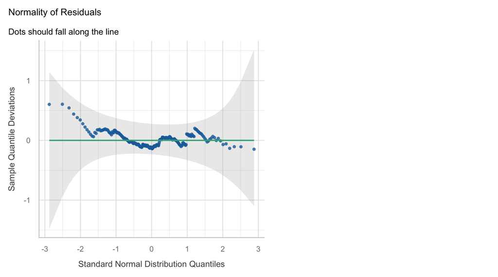

```r
check_model(mod1,  check = "qq")
```

## Some other assumptions

- the number of datapoints is greater than the number of predictors
- there is some variability in the values of your predictor (e.g. x is not the same)
- your predictors aren’t perfectly correlated (e.g. multicollinearity)

## A variety of transformations exist to normalize skewed data

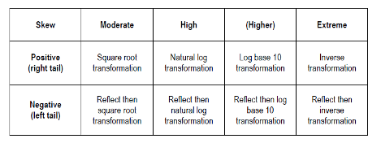

- reflect: subtract a variable from it’s maximum value - xnew = (max.value + 1 ) - xold

- Light and heavy tailed data: subtract from the median, and then transform

## Transformation tradeoffs

- A transformation may help you meet model assumptions
  - Homoscedasticity
  - Linearity
  - Normality
- But there is no guarantee that you can fix them all
- Piles of zeros are hard too (consider GLMs)

## Transformations FAQs

- Usually we are talking about transforming the Y variable, but transforming the X can also improve model fit
- Avoid classical ‘transform then linear model’ recommendations for
  - probability data or count data
  - Generally better to respect the structure of these data with a GLM

## Tools for fitting and inference

## Basic tools

- `lm` fits a linear model
- `summary` prints statistics associated with the *parameters* that were fitted

## Plotting

- `plot` can be applied to an `lm` object to give you a nice set of diagnostic tests.
- `predict` can give predicted values, and standard errors.
- In `ggplot`, `geom_smooth(method="lm")` fits a linear model to each group of data (i.e. each group that you have identified by plotting it in a different colour, within a different facet, etc.

## Assignment - Thursday

- Make a univariate linear model for one of your hypotheses
- Examine the assumptions of linearity (using diagnostic plots)
- Explain what these are telling you (it’s okay if they aren’t normal, but tell me why)
- Plot the relationship in ggplot using stat_smooth or stat_summary